# Accommodation

Author

sara

```r
library(dplyr)
library(ggplot2)
library(here)
library(pxweb)
library(scales)

purrr::map(list.files(here("R"), full.names = T), source)
```

[output not shown]

[output cut: 53 more lines]

[output not shown]

# Context

Travelling in Iceland, I want to learn something from a numbers perspective as well. here, I am examining the data available for accommodation.

# Total number of overnight stays in Iceland over time

```r
df_region <- get_accommodation_by_region()
df_aggr <- df_region |>
  group_by(year, unity) |>
  summarise(value = sum(value))
```

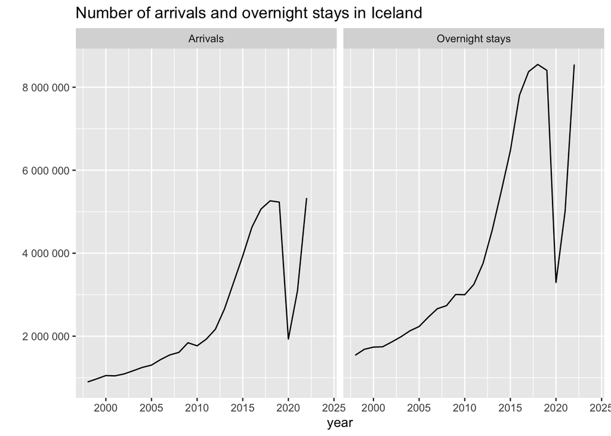

```r
df_aggr |>
  ggplot(aes(x = year, y = value)) +
  geom_line() +
  facet_wrap(vars(unity)) +
  scale_y_continuous(labels = label_number()) +
  labs(title = "Number of arrivals and overnight stays in Iceland",
       color = "",
       y = "")
```

# by month

```r
df_aggr_month <- df_region |>
  group_by(year, unity, month) |>
  summarise(value = sum(value))
```

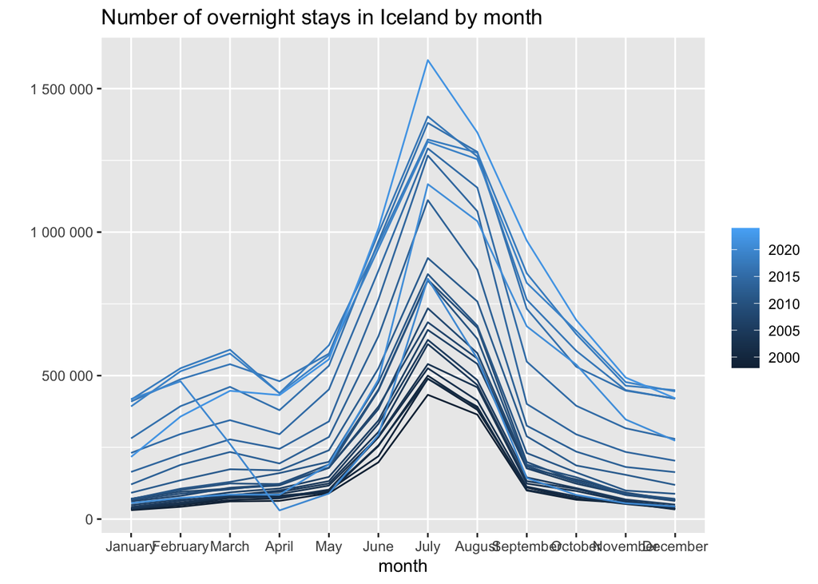

```r
df_aggr_month |>
  filter(unity == "Overnight stays") |>
  ggplot(aes(x = month, y = value, color = year, group = year)) +
  geom_line() +
  scale_y_continuous(labels = label_number()) +
  labs(title = "Number of overnight stays in Iceland by month",
       color = "",
       y = "")
```

# Swiss data as comparison

```r
df_ch <- get_accommodation_ch()
df_hotels_ch <- get_accommodation_ch(hotels_only = T)
```

## by year

aggregate data by year

```r
df_ch_year <- df_ch |>
  group_by(year, indicator) |>
  summarise(value = sum(value))
```

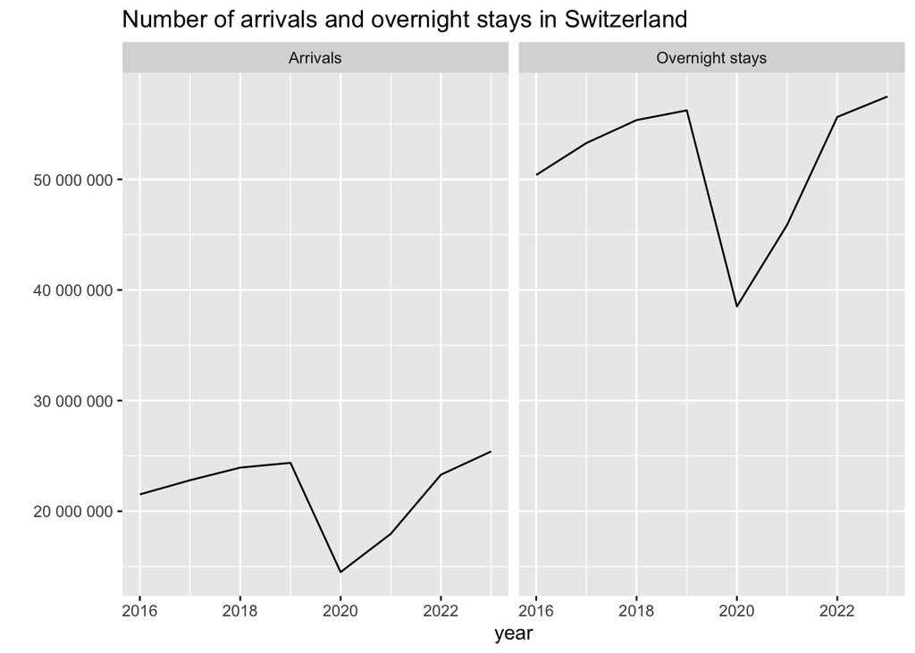

```r
df_ch_year |>
  ggplot(aes(x = year, y = value)) +
  geom_line() +
  facet_wrap(vars(indicator)) +
  scale_y_continuous(labels = label_number()) +
  labs(title = "Number of arrivals and overnight stays in Switzerland",
       color = "",
       y = "")
```

### hotels only

for a longer-term trend, look at hotels only (available since 2005 vs. 2016 for supplementary)

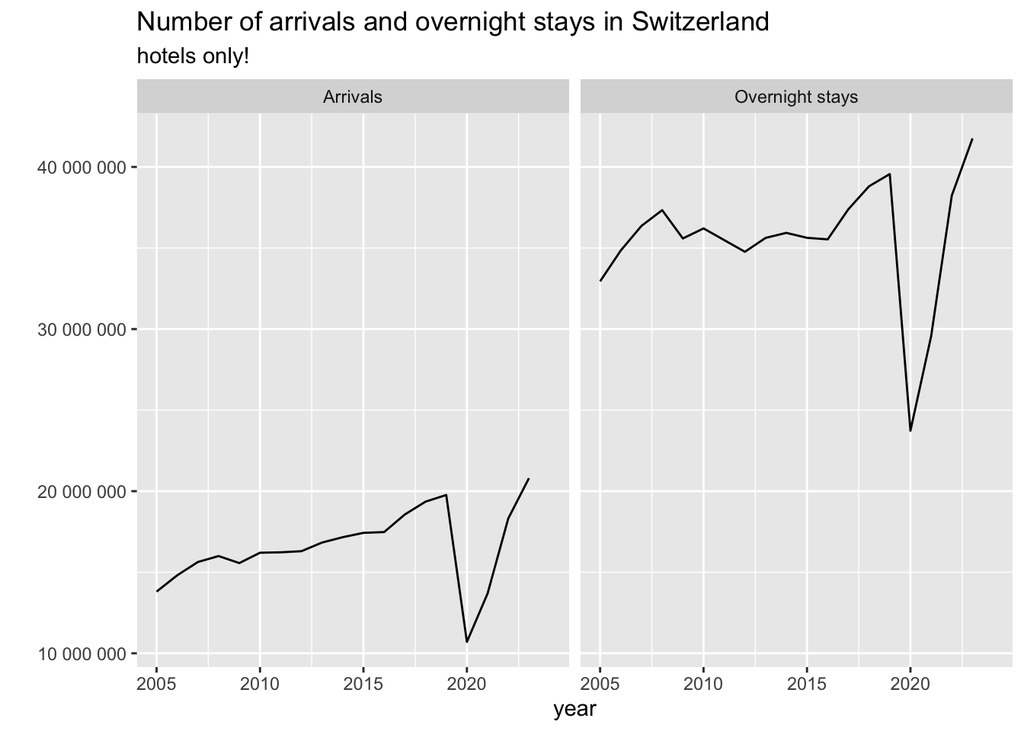

```r
df_hotels_ch_year <- df_hotels_ch |>
  group_by(year, indicator) |>
  summarise(value = sum(value))
df_hotels_ch_year |>
  ggplot(aes(x = year, y = value)) +
  geom_line() +
  facet_wrap(vars(indicator)) +
  scale_y_continuous(labels = label_number()) +
  labs(title = "Number of arrivals and overnight stays in Switzerland",
       subtitle = "hotels only!",
       color = "",
       y = "")
```

## by month

```r
df_ch_month <- df_ch |>
  group_by(year, indicator, month) |>
  summarise(value = sum(value))
```

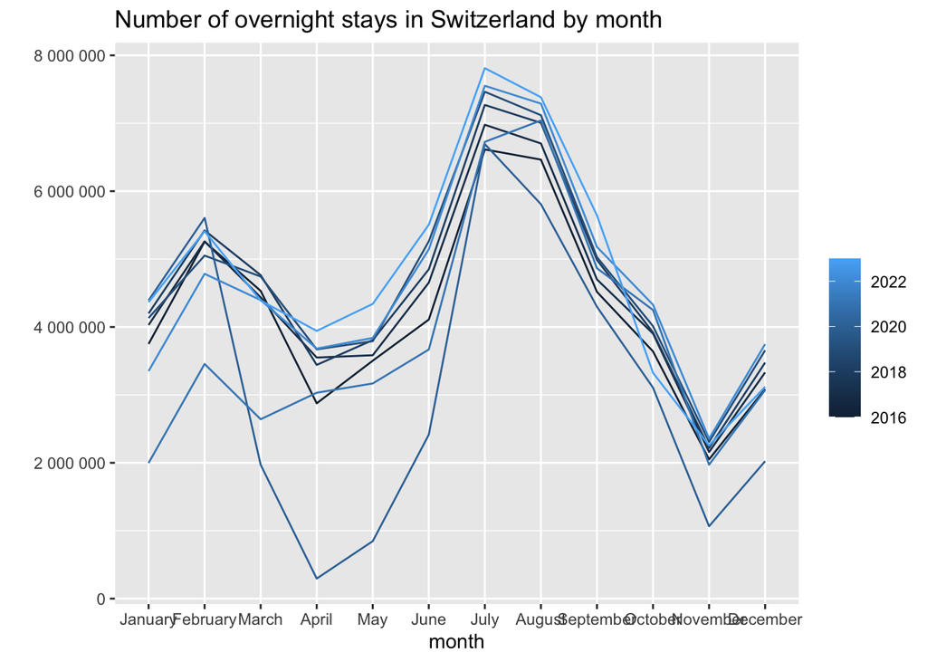

```r
df_ch_month |>
  filter(indicator == "Overnight stays") |>
  ggplot(aes(x = month, y = value, color = year, group = year)) +
  geom_line() +
  scale_y_continuous(labels = label_number()) +
  labs(title = "Number of overnight stays in Switzerland by month",
       color = "",
       y = "")
```

# data sources

## Iceland data

The Statistical Office of Icceland has a database that is accessible via an [API](https://www.scb.se/api_en/) that seems to come from the Swedish Statistical office, and handily enough has an [R package](https://github.com/rOpenGov/pxweb) as well :-)

The only negative point here is that the metadata and the json request is all in Icelandic, so there is no way I can infer anything, I have to click through the database, but ok, I get there.

## Swiss data

Hey, I thought I know my way around Swiss open data. Turns out I was about to learn something new as well… mostly that it’s a rather large pain that the data from the federal statistical office mostly are not (yet - hopefully) on the open data portal](https://opendata.swiss/de), which otherwise is an excellent source (nor are they available as [linked open data](https://lindas.admin.ch/). So I again click through a website… to learn that the numbers in [hotels](https://www.bfs.admin.ch/bfs/en/home/statistics/tourism/surveys/hesta.html) and [not-quite-hotels](https://www.bfs.admin.ch/bfs/en/home/statistics/tourism/tourist-accommodation/supplementary-accommodation.html) (apartments, campgrounds, group accommodation) are gathered and published separately, and I have to do the sums myself. And, they are not (at all!) published in the same format… sad times. Thanks to [Felix’ package](https://felixluginbuhl.com/BFS/), I can read the hotel data fairly easily, but the not-quite-hotel data… phu. Excels, again separately for apartments, campgrounds and group accommodation. This turns out to be much more work than I anticipated!

## Zurich data

The data for the city of Zurich is listed on their [open data website](https://data.stadt-zuerich.ch/dataset/zt_unterkunft) but is basically a pointer to the [API](https://zt.zuerich.com/en/open-data/v2) run by Zurich tourism. Yet another data format…